# Medical Appointments No-Show Case Study: Appointments Data Analysis

# Data set overview

## Data set overview

In this presentation we will investigate 110,000 medical appointments in Brazil & its 14 associated variables

Possibly pointing out any correlation with not showing up cases for appointments.

And also answer some of the questions regarding this data set.

However after cleaning, they were reduced to around 67,000 records.

# How many appointments did the patients not show up?

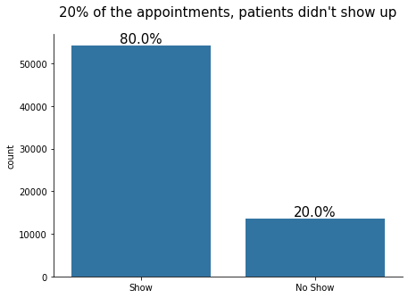

```python
counts,idx,txt = bar_data(med,'no_show')
fig=plt.figure(figsize=(7,5))
sns.countplot(data=med ,x='no_show' ,color=base_color,order=med.no_show.value_counts().index)
#plt.bar(data=med,x=idx,height=counts.values,width=0.2,align='center')
[plt.text(i, counts[idx[i]],txt[i], ha='center',va='bottom',size=15) for i in range(len(counts))];
plt.xticks([0,1],['Show','No Show'])
plt.title("20% of the appointments, patients didn't show up",fontsize=15,y=1.05)
plt.xlabel('')
sns.despine()
```

## How does age group distripution look like?

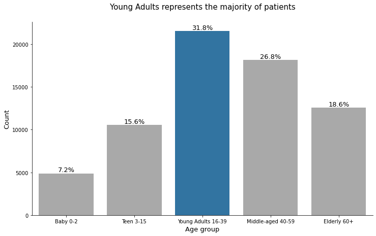

```python
counts,idx,txt = bar_data(med,'age_group')
colors = [base_color if (value == counts.max()) else '#A9A9A9' for item,value in counts.items() ]
plt.figure(figsize=(12,7))
sns.countplot(data=med,x='age_group',palette=colors);
[plt.text(i, counts[idx[i]],txt[i], ha='center',va='bottom',size=13) for i in range(len(counts))];
plt.xlabel('Age group',fontsize=13)
plt.ylabel('Count',fontsize=13)
plt.title('Young Adults represents the majority of patients',fontsize=15,y=1.05)
sns.despine()
```

# Is age related to not showing up for appointments?

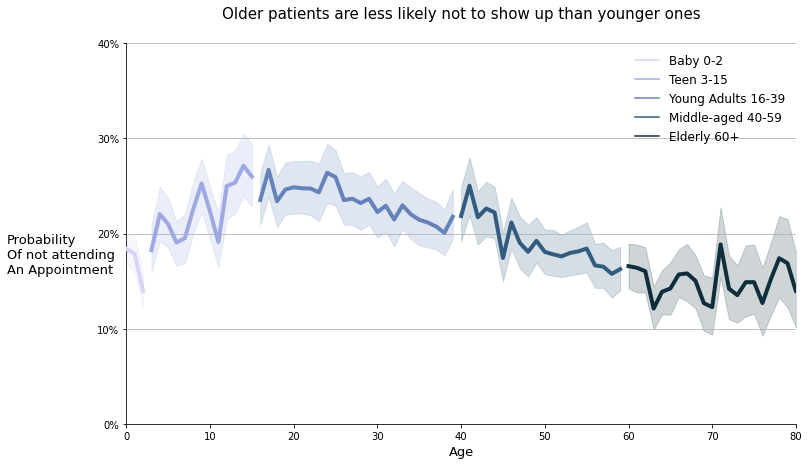

```python
fig=plt.figure(figsize=(12,7))
ax = fig.add_subplot(1,1,1)
ax.grid(zorder=0)
ax.xaxis.grid(color='gray', linestyle='-')
g=sns.lineplot(data=med, x='age',y='no_show_bin',lw=4,zorder=3,hue='age_group',
    hue_order=['Baby 0-2','Teen 3-15','Young Adults 16-39','Middle-aged 40-59', 'Elderly 60+'],
    palette=sns.cubehelix_palette(5,start=2.5,rot=0.2,hue=1))
plt.xlim(0, 80)
plt.title('Older patients are less likely not to show up than younger ones',size=15,y=1.05);
plt.ylabel('Probability\nOf not attending\nAn Appointment',size=13,rotation=0,va='top',ha='left',labelpad=90);
plt.yticks(plt.yticks()[0],pd.DataFrame(["{:.0%}".format(yy) for yy in plt.yticks()[0]])[0].values)
plt.xlabel('Age',size=13);
plt.ylim(0,0.4);
plt.legend(title=False,frameon=False,prop={'size':12})
sns.despine()
```

# What are the congested hours for scheduling appointments?

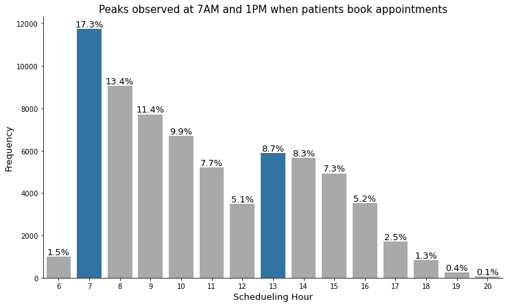

```python
counts,idx,txt = bar_data(med,'sc_hr')
fig = plt.figure(figsize=(12,7))
colors = [base_color if (hour in [7,13]) else '#A9A9A9' for hour,value in counts.items() ]
g = sns.countplot(data=med ,x='sc_hr',palette=colors)
[plt.text(i, counts[idx[i]],txt[i], ha='center',va='bottom',size=13
) for i in range(len(counts))];
# plt.xticks(np.arange(0,7,1),week_names);
plt.xlabel('Schedueling Hour',size=13);
plt.ylabel('Frequency',size=13);
plt.title("Peaks observed at 7AM and 1PM when patients book appointments",size=15);
sns.despine()
```

# Are there certain scheduling times associated with a specific age group?

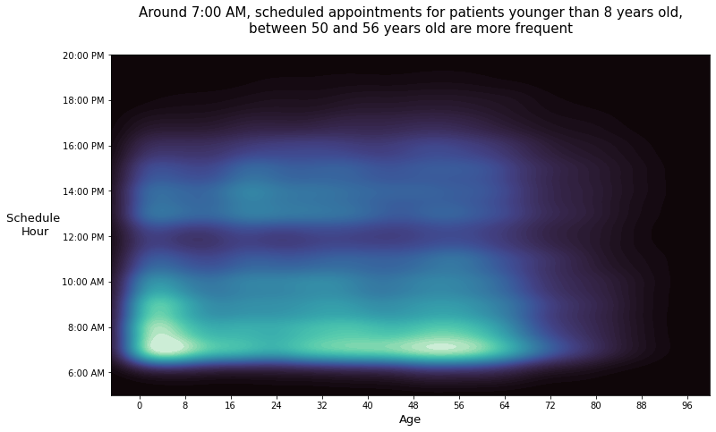

```python
def minu(t):
    t=str(t).split('.')
    if t[1]== '5':
        t[1]='30'
    else:
        t[1]='00'
    if int(t[0]) < 12:
        out= t[0]+':'+t[1]+" AM"
    else:
        out= t[0]+':'+t[1]+" PM"
    return out
fig=plt.figure(figsize=(12,7))
sns.kdeplot(data=med, y="sc_hr", x="age", fill=True, thresh=0, levels=100, cmap="mako");
plt.xlabel('Age',size=13);
plt.xticks(np.arange(0,102+8,8),np.arange(0,102+8,8))
plt.title('Around 7:00 AM, scheduled appointments for patients younger than 8 years old,\nbetween 50 and 56 years old are more frequent',y=1.05,size=15)
plt.ylabel('Schedule \nHour',size=13,rotation=0,va='center',labelpad=30);
plt.yticks(plt.yticks()[0],pd.DataFrame([minu(yy) for yy in plt.yticks()[0]])[0].values);
plt.ylim(5,20)
plt.xlim(-5,100);
```

Concentrations observed around 7AM schedule time for appointments. they are associated with patients of age less than 8 years old and between 50 and 56 years old

# Do patients tend to reschedule their appointments?

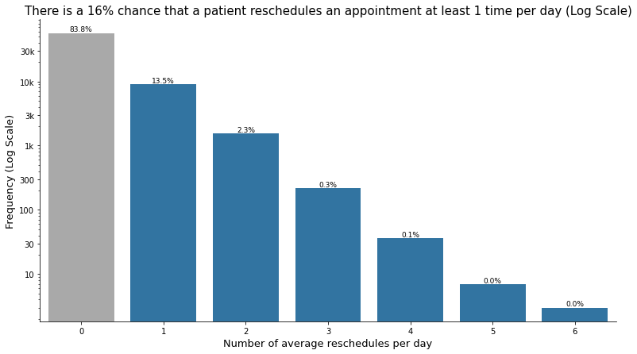

```python
counts,idx,txt=bar_data(med,'avg_re_scds_per_patient')
plt.figure(figsize=(13,7))
colors = [base_color if (index in idx[1:]) else '#A9A9A9' for index in idx ]
g=sns.countplot(data=med ,x='avg_re_scds_per_patient' ,palette=colors)
[plt.text(i, counts[idx[i]],txt[i], ha='center',va='bottom',size=9) for i in range(len(counts))];
plt.yscale('log')
plt.yticks([10,30,100,300,1000,3000,10000,30000],['10','30','100','300','1k','3k','10k','30k'])
plt.xticks(np.arange(0,6+1,1),np.arange(0,6+1,1))
plt.xlabel("Number of average reschedules per day",fontsize=13)
plt.ylabel('Frequency (Log Scale)',fontsize=13);
plt.title("There is a 16% chance that a patient reschedules an appointment at least 1 time per day (Log Scale)",fontsize=15)
sns.despine();
```

Around 84% of appointments are done using the 1st scheduling engagement!

# Do patients that reschedule their appointments during the day are more likely not to show up?

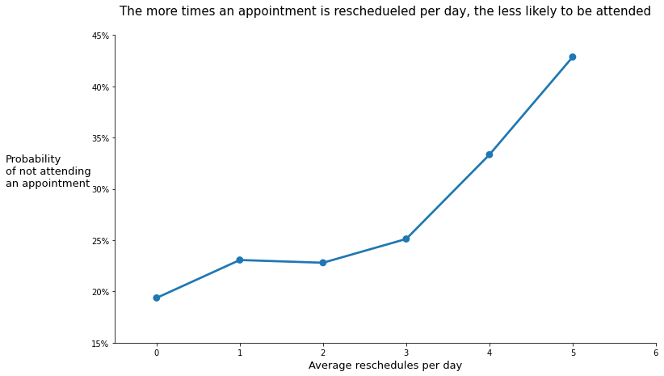

```python
fig=plt.figure(figsize=(12,7))
sns.pointplot(data=med,x='avg_re_scds_per_patient',y='no_show_bin',ci=False,order=[0,1,2,3,4,5])
plt.xlabel("Average reschedules per day",fontsize=13)
plt.ylabel('Probability\nof not attending\nan appointment',size=13,rotation=0,ha='left',labelpad=106);
plt.title("The more times an appointment is reschedueled per day, the less likely to be attended",size=15,y=1.05);
plt.yticks(plt.yticks()[0],pd.DataFrame(["{:.0%}".format(yy) for yy in plt.yticks()[0]])[0].values)
plt.xticks(np.arange(0,6+1,1),np.arange(0,6+1,1))
sns.despine()
```

## Are there any particular waiting days associated with more pre-schedueled appointments?

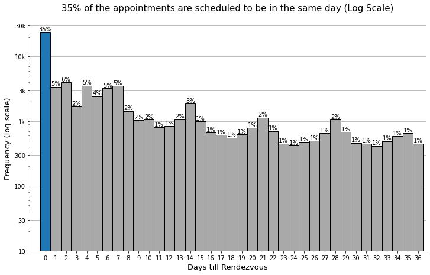

```python
fig=plt.figure(figsize=(12,7))
ax = fig.add_subplot(1,1,1)
ax.grid(zorder=0)
ax.xaxis.grid(color='#A9A9A9', linestyle='-')
bins = np.arange(0, med['waiting_days'].max()+1, 1)

freq, bins, patches =plt.hist(data=med, x='waiting_days', bins=bins,edgecolor='black',zorder=3);
bin_centers = np.diff(bins)*0.5 + bins[:-1]
plt.yscale('log')
patches[20].set_fc('#A9A9A9')
for n,(fr, x, patch) in enumerate(zip(freq, bin_centers, patches)):
  patches[n].set_fc('#A9A9A9')
  height = int(freq[n])
  plt.annotate("{:.0%}".format(height/len(med)),xy = (x, height),xytext = (0,0.2),textcoords = "offset points",
               ha = 'center', va = 'bottom')
patches[0].set_fc(base_color)
plt.xticks(np.arange(0.5,med['waiting_days'].max()+1.5,1),np.arange(0,med['waiting_days'].max()+1,1));
plt.ylabel('Frequency (log scale)');
plt.yticks([10,30,100,300,1000,3000,10000,30000],['10','30','100','300','1k','3k','10k','30k']);
plt.ylabel('Frequency (log scale)',size=13);
plt.xlabel('Days till Rendezvous',size=13);
plt.title('35% of the appointments are scheduled to be in the same day (Log Scale)',y=1.05,size=15);
plt.xlim(-1,37.25)
sns.despine()
```

However, There are peaks existing among waiting days.

## What do the peaks represent in the waiting days distribution?

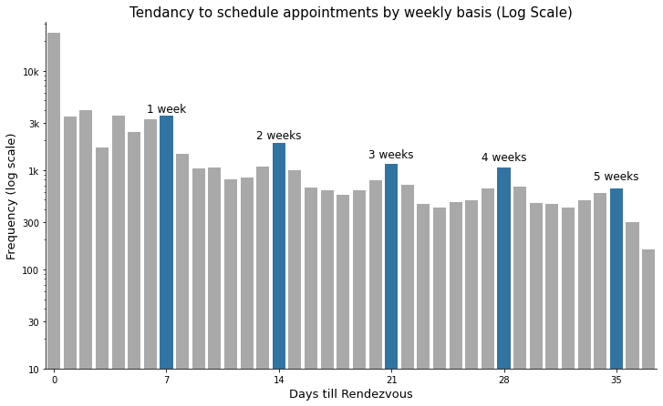

```python
wd_counts = med.waiting_days.value_counts().sort_index()
highlights =  med.waiting_days.value_counts()[[7,14,21,28,35]]
week_txt= [f"{int(ind/7)} weeks" for ind in highlights.index ]
week_txt[0]='1 week'
week= pd.Series(week_txt,index=[7,14,21,28,35])
colors = [base_color if (index in highlights.index) else '#A9A9A9' for index,value in wd_counts.items() ]
counts,idx,txt = bar_data(med,'waiting_days')
fig = plt.figure(figsize=(12,7))
g = sns.countplot(data=med ,x='waiting_days' ,palette=colors)
[plt.text(index,value+100,week[index], ha='center',va='bottom',size=12) for index,value in highlights.items() ]

plt.yscale('log')
plt.yticks([10,30,100,300,1000,3000,10000],['10','30','100','300','1k','3k','10k']);
plt.xticks(np.arange(idx.min(),idx.max()+7,7),np.arange(idx.min(),idx.max()+7,7));
plt.ylabel('Frequency (log scale)',size=13);
plt.xlabel('Days till Rendezvous',size=13);
plt.title('Tendancy to schedule appointments by weekly basis (Log Scale)',size=15);
plt.xlim(-0.5,37.5)
sns.despine()
```

The peaks represent exactly multiples of 7 days, depicting the tendancy to schedule appointments by weekly basis.

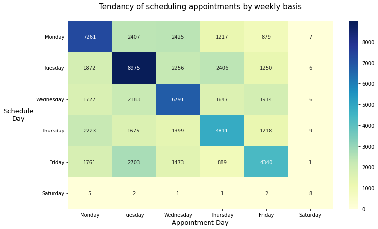

```python
week_names=['Monday','Tuesday','Wednesday','Thursday','Friday','Saturday','Sunday']
data=med.groupby(['sc_dow','ap_dow']).size().reset_index(name='count')
data_pivot=data.pivot(index='sc_dow',columns='ap_dow',values='count')
plt.figure(figsize=[12,7])
sns.heatmap(data_pivot,annot=True,fmt='d',cmap='YlGnBu',vmin=0)
plt.xticks(np.arange(0.5,5.5+1,1),week_names[:-1])
plt.yticks(np.arange(0.5,5.5+1,1),week_names[:-1],va='center',rotation=0)
plt.ylabel('Schedule\nDay',size=13,rotation=0,ha='center',va='center',labelpad=35);
plt.xlabel('Appointment Day',size=13)
plt.title('Tendancy of scheduling appointments by weekly basis',y=1.05,size=15);
```

The diagonal has the highest counts, the heat map depicts the tendancy to schedule appointments by weekly basis, as shown before in the histogram of waiting days.

# Does waiting more days relates to not attending appointments?

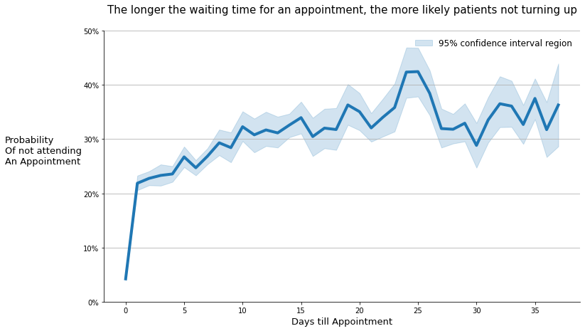

```python
fig =plt.figure(figsize=(12,7))
ax = fig.add_subplot(1,1,1)
ax.grid(zorder=0)
ax.xaxis.grid(color='gray', linestyle='-')
sns.lineplot(data=med, x='waiting_days',y='no_show_bin',lw=4,ax=ax,zorder=3)
plt.ylabel('Probability\nOf not attending\nAn Appointment',size=13,rotation=0,ha='left',va='bottom',labelpad=110);
plt.xlabel('Days till Appointment',size=13)
plt.yticks(plt.yticks()[0],pd.DataFrame(["{:.0%}".format(yy) for yy in plt.yticks()[0]])[0].values)
plt.title('The longer the waiting time for an appointment, the more likely patients not turning up',size=15,y=1.05)
sns.despine()
plt.legend(['_','95% confidence interval region'],frameon=False,prop={'size':12},loc='best');
```

# Conclusion

## Conclusion

- Around 16% of the patients rescheduel their appointment atleast 1 time per day.
- Several workdays (4-April_2016, 23-May-2016) had an unexplained inactivity.
- Tuesday is the busiest day for appointments while Thursday and Friday are the quietest, disregarding days off.
- Tuesday is the busiest day for scheduling appointments while Friday is the quietest, disregarding days off.
- Peak times where scheduling takes place are 7 AM and 1 PM.
- 35% of all the appointments are scheduled to happen in the same day, but around 4% of those appointments, their patients don't show up.